# CMS Medicare Physician & Other Practitioners by Provider dataset for 2023 preprocessing

INFO 6105 Final Project

Dany De Leriol Nohonet Sigha

2026-04-30

# Welcome

This is the data preprocessing step for the “Medicare Payment Gap Analysis in Massachussets” final project.

**Dataset:** `MUP_PHY_R25_P05_V20_D23_Prov.csv` — 1,259,343 rows, each a provider–procedure–setting combination in 2023. Each row represents the aggregated activity for a specific provider performing a specific procedure (identified by HCPCS code) in a specific care setting (facility or non-facility) over the full 2023 reporting year, capturing totals such as number of times the service was rendered, number of unique beneficiaries who received it, total submitted charges, and total Medicare payments for that provider-procedure-setting combination.

# Setup

```r
# Install if needed (uncomment once, then re-comment)

library(tidyverse)
library(haven)
library(broom)
library(car)
library(pROC)
library(boot)
library(multcomp)
library(glmnet)
library(corrplot)
library(car)
library(quantreg)

# Explicitly prefer dplyr functions over masked alternatives
select    <- dplyr::select
filter    <- dplyr::filter
summarise <- dplyr::summarise

theme_set(theme_minimal(base_size = 13))
```

# Part 1: payment gap exploration

**Payment gap in Massachussets:**

payment_gap = Tot_Sbmtd_Chrg - Tot_Mdcr_Stdzd_Amt

Tot_Sbmtd_Chrg corresponds to the total charges that the provider submitted for all services.

Tot_Mdcr_Stdzd_Amt is the total amount that Medicare paid after deductible and coinsurance amounts have been deducted for the line item service and after standardization of the Medicare payment has been applied.

**Why?** The Tot_Mdcr_Stdzd_Amt removes geographic adjustments for local wages and input prices, such as the Medicare Geographic Practice Cost Index, making payment levels comparable across Massachusetts geographies.

The payment gap as constructed captures two distinct phenomena that the first research question explicitly accounts for. First, it may reflect provider billing intensity, providers who systematically submit charges far above what Medicare considers reasonable for the services rendered. Second, it may reflect patient complexity, sicker patients generate more expensive services, and since Medicare’s payment covers only the non-deductible, non-coinsurance portion, providers serving higher-complexity panels will mechanically show larger gaps even if their billing behavior is identical to providers serving healthier patients. These two phenomena are disentangled in the regression analysis (RQ1) by controlling for average beneficiary risk score (Bene_Avg_Risk_Scre) and chronic condition prevalence (Bene_CC_*).

**The approach:**

1. Filter data on records where Rndrng_Prvdr_State_Abrvtn is “MA”
2. Create a payment_gap variable where payment_gap = Tot_Sbmtd_Chrg - Tot_Mdcr_Stdzd_Amt
3. Compute services per beneficiary srvcs_per_bene = Tot_Srvcs / Tot_Benes. This ratio can give insight into over billing patterns
4. Generate a summary of the payment gap data

```r
# Load the Medicare Physician & Other Practitioners by Provider dataset (CMS, 2023)
cms_data <- read_csv("../data/raw/MUP_PHY_R25_P05_V20_D23_Prov.csv")
#glimpse(cms_data)

# ── Step 1: Massachusetts subset ──────────────────────────────────────────────────────
ma_providers <- cms_data %>%
  filter(Rndrng_Prvdr_State_Abrvtn == "MA")

# ── Step 2: Create payment gap variable ──────────────────────────────────────────────────────
ma_providers <- ma_providers %>%
  mutate(payment_gap = Tot_Sbmtd_Chrg - Tot_Mdcr_Stdzd_Amt)

# ── Step 3: Create services per beneficiary ratio variable ──────────────────────────────────
ma_providers <- ma_providers %>%
  mutate(srvcs_per_bene = Tot_Srvcs / Tot_Benes)

# ── Structure ─────────────────────────────────────────────────────────────────
cat("Number of MA providers:", nrow(ma_providers), "\n")
```

```
## Number of MA providers: 37713
```

```r
cat("Number of variables:", ncol(ma_providers), "\n")
```

```
## Number of variables: 83
```

```r
glimpse(ma_providers)
```

```
## Rows: 37,713
## Columns: 83
## $ Rndrng_NPI                       <dbl> 1003002312, 1003007477, 1003008244, 1…
## $ Rndrng_Prvdr_Last_Org_Name       <chr> "Hopkins", "Abdow", "Rajbhandari", "R…
## $ Rndrng_Prvdr_First_Name          <chr> "Patricia", "Kimberly", "Ruma", "Alak…
## $ Rndrng_Prvdr_MI                  <chr> "T", "B", NA, NA, "P", "E", "F", "A",…
## $ Rndrng_Prvdr_Crdntls             <chr> "M.D.", "N.P.", NA, "M.D.", "RN FNP",…
## $ Rndrng_Prvdr_Ent_Cd              <chr> "I", "I", "I", "I", "I", "I", "I", "I…
## $ Rndrng_Prvdr_St1                 <chr> "571 Main St", "435 Shrewsbury St", "…
## $ Rndrng_Prvdr_St2                 <chr> NA, NA, NA, "55 Fruit Street", NA, NA…
## $ Rndrng_Prvdr_City                <chr> "Weymouth", "Worcester", "Boston", "B…
## $ Rndrng_Prvdr_State_Abrvtn        <chr> "MA", "MA", "MA", "MA", "MA", "MA", "…
## $ Rndrng_Prvdr_State_FIPS          <chr> "25", "25", "25", "25", "25", "25", "…
## $ Rndrng_Prvdr_Zip5                <chr> "02190", "01609", "02115", "02114", "…
## $ Rndrng_Prvdr_RUCA                <dbl> 1, 1, 1, 1, 1, 1, 2, 1, 1, 1, 1, 1, 1…
```

[output cut: 70 more lines]

```r
# ── Step 4: Payment gap data summary ──────────────────────────────────
cat("\n── Payment Gap Summary (MA) ──\n")
```

```
##
## ── Payment Gap Summary (MA) ──
```

```r
summary(ma_providers$payment_gap)
```

```
##      Min.   1st Qu.    Median      Mean   3rd Qu.      Max.
##    -16906     27550     89276    247719    227411 191830475
```

```r
# Total beneficiaries and services
cat("\n── Total Beneficiaries Summary (MA) ──\n")
```

```
##
## ── Total Beneficiaries Summary (MA) ──
```

```r
summary(ma_providers$Tot_Benes)
```

```
##     Min.  1st Qu.   Median     Mean  3rd Qu.     Max.
##     11.0     55.0    149.0    311.9    327.0 203417.0
```

```r
cat("\n── Total Services Summary (MA) ──\n")
```

```
##
## ── Total Services Summary (MA) ──
```

```r
summary(ma_providers$Tot_Srvcs)
```

```
##    Min. 1st Qu.  Median    Mean 3rd Qu.    Max.
##      11     166     426    1764    1153 3293072
```

```r
# The payment gap summary above reveals a negative minimum, indicating a small
# number of providers where Tot_Mdcr_Stdzd_Amt exceeds Tot_Sbmtd_Chrg.
# These 5 records are anomalous — Medicare's geographic standardization
# adjustment can marginally inflate the standardized payment above the
# submitted charge in edge cases, producing a negative gap that has no
# meaningful interpretation. They are removed here before any downstream
# analysis, as they would also produce NaN values under log transformation.

cat("── Rows with payment_gap <= 0 (removed) ──\n")
```

```
## ── Rows with payment_gap <= 0 (removed) ──
```

```r
cat(sum(ma_providers$payment_gap <= 0), "\n")
```

```
## 5
```

```r
ma_providers <- ma_providers %>%
  filter(payment_gap > 0)

cat("── Remaining MA provider rows after filter ──\n")
```

```
## ── Remaining MA provider rows after filter ──
```

```r
cat(nrow(ma_providers), "\n")
```

```
## 37708
```

```r
# ──Payment gap data summary ──────────────────────────────────
cat("\n── Payment Gap Summary (MA) ──\n")
```

```
##
## ── Payment Gap Summary (MA) ──
```

```r
summary(ma_providers$payment_gap)
```

```
##      Min.   1st Qu.    Median      Mean   3rd Qu.      Max.
##        30     27589     89292    247753    227424 191830475
```

# Part 2: specialties exploration

**Specialties of Massachussets providers:**

We identify the different provider specialties to investigate the impact they may have on the payment gap.

**Why?** Provider specialty, is categorical with multiple levels, and the goal is to test whether group means differ simultaneously rather than through a series of pairwise comparisons. The analysis focuses on the top 10 specialties by provider count to ensure adequate group sizes for assumption checking.

**The approach:**

1. Count the number of distinct specialties in the dataset
2. Find the Top 10 specialties by provider count

```r
# Provider specialties — categorical variable for ANOVA
# ── Step 1: Distinct specialties count ──────────────────────────────────────────────────────
cat("\n── Number of unique specialties ──\n")
```

```
##
## ── Number of unique specialties ──
```

```r
cat(length(unique(ma_providers$Rndrng_Prvdr_Type)), "\n")
```

```
## 97
```

```r
# ── Step 2: Top 10 specialties by provider count ────────────────────────────────────────────
cat("\n── Top 10 specialties by provider count ──\n")
```

```
##
## ── Top 10 specialties by provider count ──
```

```r
ma_providers %>%
  count(Rndrng_Prvdr_Type, sort = TRUE) %>%
  head(10) %>%
  print()
```

```
## # A tibble: 10 × 2
##    Rndrng_Prvdr_Type                          n
##    <chr>                                  <int>
##  1 Nurse Practitioner                      5496
##  2 Internal Medicine                       3978
##  3 Physician Assistant                     3070
##  4 Physical Therapist in Private Practice  2005
##  5 Anesthesiology                          1375
##  6 Family Practice                         1335
##  7 Emergency Medicine                      1299
##  8 Diagnostic Radiology                    1118
##  9 Licensed Clinical Social Worker         1044
## 10 Psychiatry                              1033
```

```r
# ── Step 3: Top 20 specialties by provider count ────────────────────────────────────────────
cat("\n── Top 10 specialties by provider count ──\n")
```

```
##
## ── Top 10 specialties by provider count ──
```

```r
ma_providers %>%
  count(Rndrng_Prvdr_Type, sort = TRUE) %>%
  head(20) %>%
  print()
```

```
## # A tibble: 20 × 2
##    Rndrng_Prvdr_Type                                 n
##    <chr>                                         <int>
##  1 Nurse Practitioner                             5496
##  2 Internal Medicine                              3978
##  3 Physician Assistant                            3070
##  4 Physical Therapist in Private Practice         2005
##  5 Anesthesiology                                 1375
##  6 Family Practice                                1335
##  7 Emergency Medicine                             1299
##  8 Diagnostic Radiology                           1118
##  9 Licensed Clinical Social Worker                1044
## 10 Psychiatry                                     1033
## 11 Certified Registered Nurse Anesthetist (CRNA)   980
## 12 Optometry                                       843
## 13 Cardiology                                      705
## 14 Chiropractic                                    696
## 15 Obstetrics & Gynecology                         683
## 16 Neurology                                       651
## 17 Mass Immunizer Roster Biller                    617
## 18 Hospitalist                                     596
## 19 Psychologist, Clinical                          574
## 20 Ophthalmology                                   564
```

# Part 3: missing values check

**Why check for missing values?**

Before any inferential analysis, it is essential to confirm that the key variables contain no missing entries. Missing values in outcome variables such as `payment_gap` or in predictors such as `Bene_Avg_Risk_Scre` would silently drop observations from regression models, potentially introducing selection bias. The check below covers every variable that enters the regression, ANOVA, logistic regression, or permutation test.

`srvcs_per_bene` receives a separate `NaN` check in addition to the standard `NA` check. Because it is a derived ratio (`Tot_Srvcs / Tot_Benes`), any row where `Tot_Benes` is zero would produce `NaN` rather than `NA` — R’s division-by-zero result for numeric vectors. Standard `is.na()` returns `TRUE` for `NaN`, so the count below will catch both, but the explicit `is.nan()` check makes the distinction visible and confirms whether the issue is upstream missing data or a zero-beneficiary edge case that may warrant filtering before modelling.

CMS suppresses chronic condition prevalence values (`Bene_CC_*`) when fewer than 11 beneficiaries with that condition were observed for a given provider. Missingness in these variables is therefore not random — it is systematically more likely for providers with small patient panels or rare specialties. The investigation below checks whether missing values cluster among low-volume providers, which would confirm the suppression mechanism and guide the handling strategy for downstream analyses.

```r
cat("── Total MA provider rows ──\n")
```

```
## ── Total MA provider rows ──
```

```r
cat(nrow(ma_providers), "\n")
```

```
## 37708
```

```r
cat("\n── Missing values in key non-CC variables ──\n")
```

```
##
## ── Missing values in key non-CC variables ──
```

```r
ma_providers %>%
  dplyr::select(
    payment_gap,
    Tot_Sbmtd_Chrg,
    Tot_Mdcr_Stdzd_Amt,
    Tot_Benes,
    Tot_Srvcs,
    srvcs_per_bene,
    Rndrng_Prvdr_Type,
    Rndrng_Prvdr_RUCA_Desc,
    Bene_Avg_Age,
    Bene_Avg_Risk_Scre
  ) %>%
  summarise(across(everything(), ~sum(is.na(.)))) %>%
  tidyr::pivot_longer(everything(),
    names_to  = "variable",
    values_to = "n_missing"
  ) %>%
  print()
```

```
## # A tibble: 10 × 2
##    variable               n_missing
##    <chr>                      <int>
##  1 payment_gap                    0
##  2 Tot_Sbmtd_Chrg                 0
##  3 Tot_Mdcr_Stdzd_Amt             0
##  4 Tot_Benes                      0
##  5 Tot_Srvcs                      0
##  6 srvcs_per_bene                 0
##  7 Rndrng_Prvdr_Type              0
##  8 Rndrng_Prvdr_RUCA_Desc        26
##  9 Bene_Avg_Age                   0
## 10 Bene_Avg_Risk_Scre             0
```

```r
cat("\n── NaN check for srvcs_per_bene (division-by-zero guard) ──\n")
```

```
##
## ── NaN check for srvcs_per_bene (division-by-zero guard) ──
```

```r
cat("NaN count:", sum(is.nan(ma_providers$srvcs_per_bene)), "\n")
```

```
## NaN count: 0
```

```r
cat("NA count: ", sum(is.na(ma_providers$srvcs_per_bene)),  "\n")
```

```
## NA count:  0
```

```r
cat("\n── Missing values in all Bene_CC_* variables (with % of total rows) ──\n")
```

```
##
## ── Missing values in all Bene_CC_* variables (with % of total rows) ──
```

```r
ma_providers %>%
  dplyr::select(starts_with("Bene_CC_")) %>%
  summarise(across(everything(), ~sum(is.na(.)))) %>%
  tidyr::pivot_longer(everything(),
    names_to  = "variable",
    values_to = "n_missing"
  ) %>%
  mutate(pct_missing = round(n_missing / nrow(ma_providers) * 100, 1)) %>%
  arrange(desc(n_missing)) %>%
  print(n = Inf)
```

```
## # A tibble: 25 × 3
##    variable                         n_missing pct_missing
##    <chr>                                <int>       <dbl>
##  1 Bene_CC_BH_ADHD_OthCD_V1_Pct         25690        68.1
##  2 Bene_CC_BH_PD_V1_Pct                 24991        66.3
##  3 Bene_CC_PH_Parkinson_V2_Pct          22776        60.4
##  4 Bene_CC_BH_PTSD_V1_Pct               22363        59.3
##  5 Bene_CC_BH_Schizo_OthPsy_V1_Pct      21543        57.1
##  6 Bene_CC_BH_Bipolar_V1_Pct            16601        44
##  7 Bene_CC_BH_Alcohol_Drug_V1_Pct       15264        40.5
##  8 Bene_CC_BH_Alz_NonAlzdem_V2_Pct      14549        38.6
##  9 Bene_CC_PH_Stroke_TIA_V2_Pct         14070        37.3
## 10 Bene_CC_BH_Tobacco_V1_Pct            13731        36.4
## 11 Bene_CC_PH_Asthma_V2_Pct             11487        30.5
## 12 Bene_CC_PH_HF_NonIHD_V2_Pct          10746        28.5
## 13 Bene_CC_PH_COPD_V2_Pct               10614        28.1
## 14 Bene_CC_PH_Osteoporosis_V2_Pct       10223        27.1
## 15 Bene_CC_PH_Cancer6_V2_Pct            10204        27.1
## 16 Bene_CC_PH_Afib_V2_Pct                9736        25.8
## 17 Bene_CC_PH_CKD_V2_Pct                 8239        21.8
## 18 Bene_CC_PH_IschemicHeart_V2_Pct       8151        21.6
## 19 Bene_CC_PH_Diabetes_V2_Pct            7117        18.9
## 20 Bene_CC_BH_Depress_V1_Pct             5474        14.5
## 21 Bene_CC_BH_Anxiety_V1_Pct             4421        11.7
## 22 Bene_CC_BH_Mood_V2_Pct                4391        11.6
## 23 Bene_CC_PH_Arthritis_V2_Pct           4175        11.1
## 24 Bene_CC_PH_Hypertension_V2_Pct        2265         6
## 25 Bene_CC_PH_Hyperlipidemia_V2_Pct      2188         5.8
```

```r
# Flag providers with at least one missing Bene_CC_* value
ma_providers <- ma_providers %>%
  mutate(any_cc_missing = if_any(starts_with("Bene_CC_"), is.na))

cat("── Providers with at least one missing Bene_CC_* value ──\n")
```

```
## ── Providers with at least one missing Bene_CC_* value ──
```

```r
table(ma_providers$any_cc_missing)
```

```
##
## FALSE  TRUE
##  3752 33956
```

```r
cat("\n── Tot_Benes distribution: complete vs incomplete CC rows ──\n")
```

```
##
## ── Tot_Benes distribution: complete vs incomplete CC rows ──
```

```r
ma_providers %>%
  group_by(any_cc_missing) %>%
  summarise(
    n            = n(),
    median_benes = median(Tot_Benes),
    mean_benes   = round(mean(Tot_Benes), 1),
    p25_benes    = quantile(Tot_Benes, 0.25),
    p75_benes    = quantile(Tot_Benes, 0.75)
  ) %>%
  print()
```

```
## # A tibble: 2 × 6
##   any_cc_missing     n median_benes mean_benes p25_benes p75_benes
##   <lgl>          <int>        <dbl>      <dbl>     <dbl>     <dbl>
## 1 FALSE           3752         928.      1424.       533      1611
## 2 TRUE           33956         125        189         48       257
```

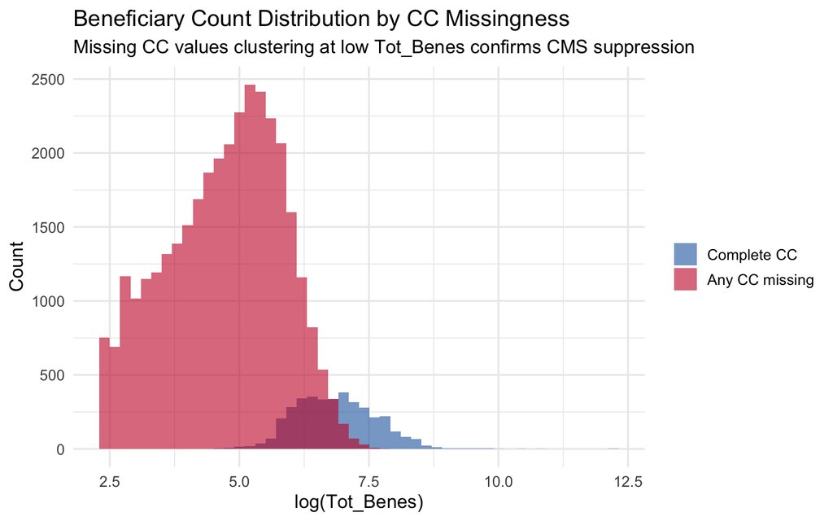

```r
ggplot(ma_providers, aes(x = log(Tot_Benes), fill = any_cc_missing)) +
  geom_histogram(bins = 50, position = "identity", alpha = 0.6) +
  scale_fill_manual(
    values = c("FALSE" = "#2166AC", "TRUE" = "#C8102E"),
    labels = c("FALSE" = "Complete CC", "TRUE" = "Any CC missing")
  ) +
  labs(
    title    = "Beneficiary Count Distribution by CC Missingness",
    subtitle = "Missing CC values clustering at low Tot_Benes confirms CMS suppression",
    x        = "log(Tot_Benes)",
    y        = "Count",
    fill     = NULL
  )
```

# Part 4: chronic condition prevalence validation

**Why validate the `Bene_CC_*` range?**

The chronic condition prevalence variables are percentages derived from CMS beneficiary records. Two CMS privacy protection rules shape the expected range of these variables.

First, prevalence values are suppressed entirely (`NA`) when fewer than 11 beneficiaries with that condition were observed for a given provider — the mechanism identified in Part 3.

Second, values between 75% and 100% are top-coded at 75%. A provider whose patient panel is, say, 90% diabetic will have that figure reported as 75%. This prevents re-identification of providers with very small, homogeneous patient panels.

The valid range for non-suppressed values is therefore **[0, 75]**, not [0, 1] or [0, 100]. A maximum of exactly 75 across all variables is expected and confirms CMS top-coding is applied consistently. Any value above 75 would indicate a data encoding error. This check is a precondition for the use of these variables in the regression analysis (RQ1) and serves as documentation of a known ceiling effect that slightly compresses the upper tail of the chronic condition distributions.

```r
cc_vars <- ma_providers %>%
  dplyr::select(starts_with("Bene_CC_"))

cat("\n── Chronic condition prevalence variables: range check ──\n")
```

```
##
## ── Chronic condition prevalence variables: range check ──
```

```r
cc_vars %>%
  summarise(across(everything(), list(
    min  = ~min(., na.rm = TRUE),
    max  = ~max(., na.rm = TRUE)
  ))) %>%
  tidyr::pivot_longer(everything(),
    names_to  = c("variable", ".value"),
    names_sep = "_(?=[^_]+$)"
  ) %>%
  print(n = Inf)
```

```
## # A tibble: 25 × 3
##    variable                           min   max
##    <chr>                            <dbl> <dbl>
##  1 Bene_CC_BH_ADHD_OthCD_V1_Pct         0    75
##  2 Bene_CC_BH_Alcohol_Drug_V1_Pct       0    75
##  3 Bene_CC_BH_Tobacco_V1_Pct            0    75
##  4 Bene_CC_BH_Alz_NonAlzdem_V2_Pct      0    75
##  5 Bene_CC_BH_Anxiety_V1_Pct            0    75
##  6 Bene_CC_BH_Bipolar_V1_Pct            0    75
##  7 Bene_CC_BH_Mood_V2_Pct               0    75
##  8 Bene_CC_BH_Depress_V1_Pct            0    75
##  9 Bene_CC_BH_PD_V1_Pct                 0    75
## 10 Bene_CC_BH_PTSD_V1_Pct               0    75
## 11 Bene_CC_BH_Schizo_OthPsy_V1_Pct      0    75
## 12 Bene_CC_PH_Asthma_V2_Pct             0    75
## 13 Bene_CC_PH_Afib_V2_Pct               0    75
## 14 Bene_CC_PH_Cancer6_V2_Pct            0    75
## 15 Bene_CC_PH_CKD_V2_Pct                0    75
## 16 Bene_CC_PH_COPD_V2_Pct               0    75
## 17 Bene_CC_PH_Diabetes_V2_Pct           0    75
## 18 Bene_CC_PH_HF_NonIHD_V2_Pct          0    75
## 19 Bene_CC_PH_Hyperlipidemia_V2_Pct     0    75
## 20 Bene_CC_PH_Hypertension_V2_Pct       0    75
## 21 Bene_CC_PH_IschemicHeart_V2_Pct      0    75
## 22 Bene_CC_PH_Osteoporosis_V2_Pct       0    75
## 23 Bene_CC_PH_Parkinson_V2_Pct          0    75
## 24 Bene_CC_PH_Arthritis_V2_Pct          0    75
## 25 Bene_CC_PH_Stroke_TIA_V2_Pct         0    75
```

# Part 5: payment gap distribution

**What to look for:**

The raw payment gap distribution is expected to be heavily right-skewed — a small number of high-volume specialists submit very large charges relative to Medicare reimbursement, pulling the tail far to the right. This skew motivates using the log-transformed gap as the outcome in the multiple regression (RQ1) and justifies bootstrap rather than parametric confidence intervals for the permutation test (RQ4).

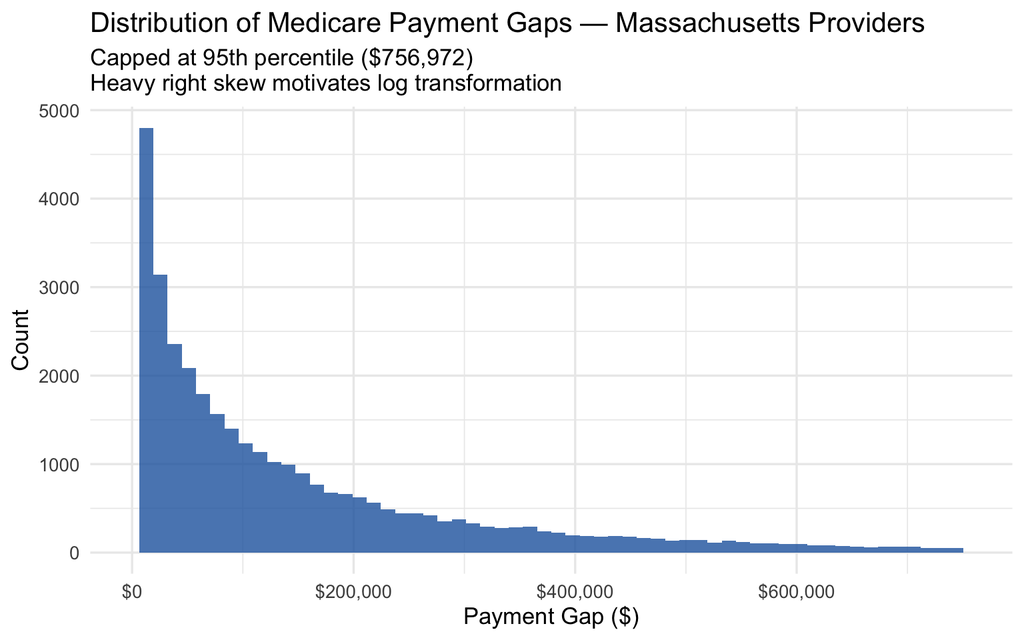

Distribution of Medicare payment gaps for Massachusetts providers (2023). The distribution is heavily right-skewed — the x-axis is capped at the 95th percentile for visibility, with the remaining 5% of providers extending well beyond this range.

```r
p95 <- quantile(ma_providers$payment_gap, 0.95)

ggplot(ma_providers, aes(x = payment_gap)) +
  geom_histogram(bins = 60, fill = "#2166AC", alpha = 0.8) +
  scale_x_continuous(
    labels = scales::dollar,
    limits = c(0, p95)
  ) +
  labs(
    title    = "Distribution of Medicare Payment Gaps — Massachusetts Providers",
    subtitle = paste0("Capped at 95th percentile ($",
                      scales::comma(round(p95)),
                      ")\nHeavy right skew motivates log transformation"),
    x        = "Payment Gap ($)",
    y        = "Count"
  )
```

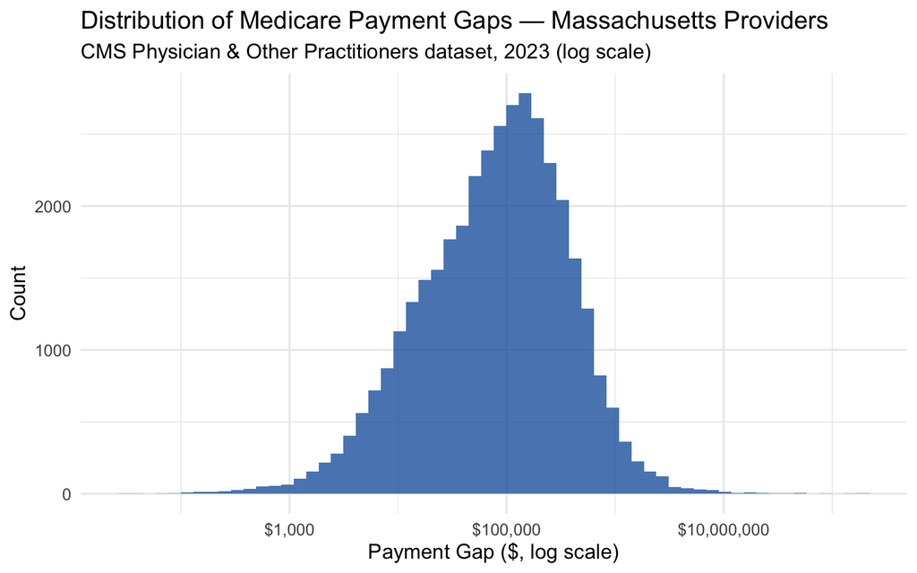

```r
ggplot(ma_providers, aes(x = payment_gap)) +
  geom_histogram(bins = 60, fill = "#2166AC", alpha = 0.8) +
  scale_x_log10(labels = scales::dollar) +
  labs(
    title    = "Distribution of Medicare Payment Gaps — Massachusetts Providers",
    subtitle = "CMS Physician & Other Practitioners dataset, 2023 (log scale)",
    x        = "Payment Gap ($, log scale)",
    y        = "Count"
  )
```

# Part 6: Motivation for quantile regression

**Why examine quantile regression before fitting OLS?** Multiple linear regression estimates a single coefficient per predictor — the average effect of that predictor across all providers. This average is meaningful only if the effect is roughly uniform across the payment gap distribution. If billing intensity, for example, drives the gap more strongly among low-gap providers than high-gap ones, OLS will split the difference and miss that heterogeneity entirely.

These exploratory plots overlay univariate quantile regression fits at Q25, Q50, and Q75 on the raw scatter of log(payment_gap) against each predictor. The Q25 line traces the relationship for providers in the bottom quarter of the gap distribution at each level of the predictor; the Q75 line does the same for providers in the top quarter. If the three lines are parallel and equally spaced, OLS is telling the complete story. If they fan out, converge, or diverge in slope, that is visual evidence that the predictor behaves differently across the distribution — and that quantile regression will reveal something OLS cannot.

**Note:** These are univariate fits for visualization purposes only. The full multivariate quantile regression results are reported after Model 1.

**What to look for:**

For **log(Tot_Benes)**: if the quantile lines converge as volume increases — Q25 and Q75 drawing closer together at high volume — this suggests that among high-volume providers the gap distribution is tighter and more predictable from volume alone. Among low-volume providers, other factors drive larger spread in the gap, which is consistent with the heteroscedasticity observed in the Model 1 diagnostic plots.

For **log(srvcs_per_bene)**: parallel quantile lines with large vertical separation between Q25 and Q75 would suggest that billing intensity shifts the gap level uniformly across the distribution, but does not explain why some providers are structurally high-gap and others low-gap. A narrowing or crossing of lines would indicate differential effects worth investigating in the full multivariate quantile regression.

In both cases, the OLS line is shown as a dotted reference. Quantile lines that stray away from the OLS line confirm that the single average estimate is insufficient to characterize the full relationship between each predictor and the payment gap.

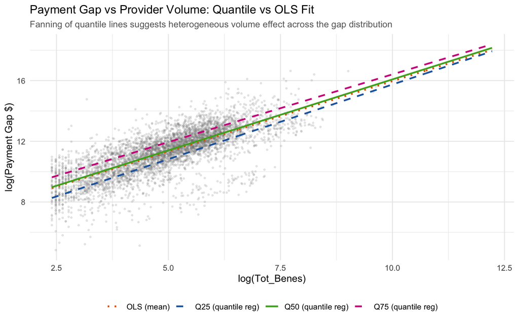

```r
# Fit quantile regression lines at Q25, Q50, Q75
# and OLS for comparison — on log(payment_gap) ~ log(Tot_Benes)
qr_25 <- rq(log(payment_gap) ~ log(Tot_Benes), tau = 0.25, data = ma_providers)
qr_50 <- rq(log(payment_gap) ~ log(Tot_Benes), tau = 0.50, data = ma_providers)
qr_75 <- rq(log(payment_gap) ~ log(Tot_Benes), tau = 0.75, data = ma_providers)
ols   <- lm(log(payment_gap) ~ log(Tot_Benes), data = ma_providers)

# Build prediction grid
benes_grid <- data.frame(
  Tot_Benes = exp(seq(
    min(log(ma_providers$Tot_Benes)),
    max(log(ma_providers$Tot_Benes)),
    length.out = 300
  ))
)

pred_df <- benes_grid %>%
  mutate(
    q25 = predict(qr_25, newdata = benes_grid),
    q50 = predict(qr_50, newdata = benes_grid),
    q75 = predict(qr_75, newdata = benes_grid),
    ols = predict(ols,   newdata = benes_grid)
  ) %>%
  pivot_longer(cols = c(q25, q50, q75, ols),
               names_to = "model", values_to = "fitted_log_gap")

# Sample points to avoid overplotting (5,000 random providers)
set.seed(6105)
plot_sample <- ma_providers %>% sample_n(5000)

ggplot() +
  geom_point(
    data  = plot_sample,
    aes(x = log(Tot_Benes), y = log(payment_gap)),
    alpha = 0.15, size = 0.6, colour = "grey50"
  ) +
  geom_line(
    data = pred_df,
    aes(x = log(Tot_Benes), y = fitted_log_gap,
        colour = model, linetype = model),
    linewidth = 0.9
  ) +
  scale_colour_manual(
    values = c(
      q25 = "#2166AC",
      q50 = "#4DAC26",
      q75 = "#D01C8B",
      ols = "#E66101"
    ),
    labels = c(
      q25 = "Q25 (quantile reg)",
      q50 = "Q50 (quantile reg)",
      q75 = "Q75 (quantile reg)",
      ols = "OLS (mean)"
    )
  ) +
  scale_linetype_manual(
    values = c(q25 = "dashed", q50 = "solid", q75 = "dashed", ols = "dotted"),
    labels = c(
      q25 = "Q25 (quantile reg)",
      q50 = "Q50 (quantile reg)",
      q75 = "Q75 (quantile reg)",
      ols = "OLS (mean)"
    )
  ) +
  labs(
    title    = "Payment Gap vs Provider Volume: Quantile vs OLS Fit",
    subtitle = "Fanning of quantile lines suggests heterogeneous volume effect across the gap distribution",
    x        = "log(Tot_Benes)",
    y        = "log(Payment Gap $)",
    colour   = NULL,
    linetype = NULL
  ) +
  theme_minimal() +
  theme(
    plot.title    = element_text(size = 13),
    plot.subtitle = element_text(size = 10, colour = "grey40"),
    legend.position = "bottom"
  )
```

```r
ggsave(
  here::here("docs", "figures", "quantile_motivation.png"),
  width = 8, height = 5, dpi = 300
)
```

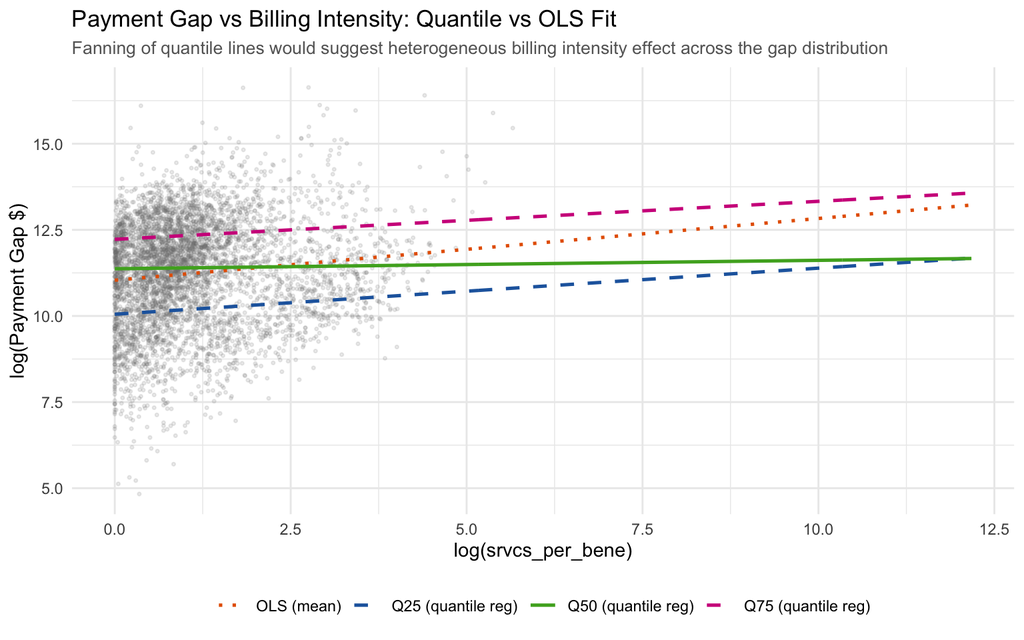

```r
# Same plot for log(srvcs_per_bene)
qr_25_s <- rq(log(payment_gap) ~ log(srvcs_per_bene), tau = 0.25, data = ma_providers)
qr_50_s <- rq(log(payment_gap) ~ log(srvcs_per_bene), tau = 0.50, data = ma_providers)
qr_75_s <- rq(log(payment_gap) ~ log(srvcs_per_bene), tau = 0.75, data = ma_providers)
ols_s   <- lm(log(payment_gap) ~ log(srvcs_per_bene), data = ma_providers)

srvcs_grid <- data.frame(
  srvcs_per_bene = exp(seq(
    min(log(ma_providers$srvcs_per_bene)),
    max(log(ma_providers$srvcs_per_bene)),
    length.out = 300
  ))
)

pred_df_s <- srvcs_grid %>%
  mutate(
    q25 = predict(qr_25_s, newdata = srvcs_grid),
    q50 = predict(qr_50_s, newdata = srvcs_grid),
    q75 = predict(qr_75_s, newdata = srvcs_grid),
    ols = predict(ols_s,   newdata = srvcs_grid)
  ) %>%
  pivot_longer(cols = c(q25, q50, q75, ols),
               names_to = "model", values_to = "fitted_log_gap")

set.seed(6105)
plot_sample_s <- ma_providers %>% sample_n(5000)

ggplot() +
  geom_point(
    data  = plot_sample_s,
    aes(x = log(srvcs_per_bene), y = log(payment_gap)),
    alpha = 0.15, size = 0.6, colour = "grey50"
  ) +
  geom_line(
    data = pred_df_s,
    aes(x = log(srvcs_per_bene), y = fitted_log_gap,
        colour = model, linetype = model),
    linewidth = 0.9
  ) +
  scale_colour_manual(
    values = c(
      q25 = "#2166AC",
      q50 = "#4DAC26",
      q75 = "#D01C8B",
      ols = "#E66101"
    ),
    labels = c(
      q25 = "Q25 (quantile reg)",
      q50 = "Q50 (quantile reg)",
      q75 = "Q75 (quantile reg)",
      ols = "OLS (mean)"
    )
  ) +
  scale_linetype_manual(
    values = c(q25 = "dashed", q50 = "solid", q75 = "dashed", ols = "dotted"),
    labels = c(
      q25 = "Q25 (quantile reg)",
      q50 = "Q50 (quantile reg)",
      q75 = "Q75 (quantile reg)",
      ols = "OLS (mean)"
    )
  ) +
  labs(
    title    = "Payment Gap vs Billing Intensity: Quantile vs OLS Fit",
    subtitle = "Fanning of quantile lines would suggest heterogeneous billing intensity effect across the gap distribution",
    x        = "log(srvcs_per_bene)",
    y        = "log(Payment Gap $)",
    colour   = NULL,
    linetype = NULL
  ) +
  theme_minimal() +
  theme(
    plot.title      = element_text(size = 13),
    plot.subtitle   = element_text(size = 10, colour = "grey40"),
    legend.position = "bottom"
  )
```

```r
ggsave(
  here::here("docs", "figures", "quantile_motivation_srvcs.png"),
  width = 8, height = 5, dpi = 300
)
```

# Part 7: payment gap by provider specialty

**Why compare payment gap across specialties?**

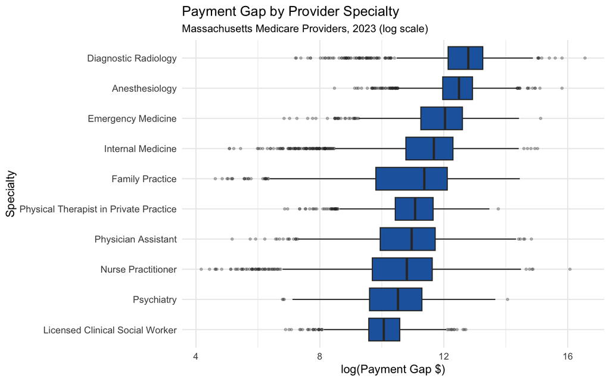

```r
ma_providers %>%
  count(Rndrng_Prvdr_Type, sort = TRUE) %>%
  head(10) %>%
  inner_join(ma_providers, by = "Rndrng_Prvdr_Type") %>%
  ggplot(aes(x    = reorder(Rndrng_Prvdr_Type, payment_gap, median),
             y    = log(payment_gap))) +
  geom_boxplot(fill = "#2166AC", outlier.alpha = 0.3, outlier.size = 0.8) +
  coord_flip() +
  labs(
    title    = "Payment Gap by Provider Specialty",
    subtitle = "Massachusetts Medicare Providers, 2023 (log scale)",
    x        = "Specialty",
    y        = "log(Payment Gap $)"
  ) +
  theme_minimal() +
  theme(
    plot.title    = element_text(size = 13),
    plot.subtitle = element_text(size = 10),
    axis.text.y   = element_text(size = 9)
  )
```

```r
cat("── Median distinct HCPCS codes by specialty — top 20 by gap ──\n")
```

```
## ── Median distinct HCPCS codes by specialty — top 20 by gap ──
```

```r
ma_providers %>%
  group_by(Rndrng_Prvdr_Type) %>%
  summarise(
    n                 = n(),
    median_gap        = median(payment_gap),
    median_hcpcs      = median(Tot_HCPCS_Cds),
    mean_hcpcs        = round(mean(Tot_HCPCS_Cds), 1),
    .groups           = "drop"
  ) %>%
  arrange(desc(median_gap)) %>%
  head(20) %>%
  mutate(median_gap = scales::dollar(round(median_gap, 0))) %>%
  print()
```

```
## # A tibble: 20 × 5
##    Rndrng_Prvdr_Type                        n median_gap median_hcpcs mean_hcpcs
##    <chr>                                <int> <chr>             <dbl>      <dbl>
##  1 Radiation Therapy Center                 1 $17,766,7…         31         31
##  2 Ambulatory Surgical Center              55 $2,996,457         38         55.9
##  3 Mammography Center                       1 $2,038,146          7          7
##  4 Portable X-Ray Supplier                  2 $1,373,946         73         73
##  5 Independent Diagnostic Testing Faci…    75 $1,260,150         19         21.5
##  6 Micrographic Dermatologic Surgery        6 $1,102,483         81         79.8
##  7 Ambulance Service Provider             279 $867,115            4          4.4
##  8 Hand Surgery                            56 $621,746           83.5       80.5
##  9 Interventional Pain Management          13 $605,746           42         40.2
## 10 Ophthalmology                          564 $579,425           30         30.9
## 11 Clinical Cardiac Electrophysiology      69 $546,770           61         56.2
## 12 Urology                                245 $525,373           61         62.9
## 13 Clinical Laboratory                     46 $524,901           18         80.5
## 14 Orthopedic Surgery                     514 $496,065           47         50.7
## 15 Interventional Cardiology               62 $496,017           53         51.8
## 16 Vascular Surgery                       104 $489,937           83.5       81.7
## 17 Radiation Oncology                     176 $435,721           28         26.9
## 18 Neurosurgery                           141 $410,154           39         39.4
## 19 Cardiac Surgery                         26 $391,270           36.5       35.1
## 20 Dermatology                            482 $367,699           36         41.4
```

```r
cat("\n── Median distinct HCPCS codes — bottom 10 by gap ──\n")
```

```
##
## ── Median distinct HCPCS codes — bottom 10 by gap ──
```

```r
ma_providers %>%
  group_by(Rndrng_Prvdr_Type) %>%
  summarise(
    n                 = n(),
    median_gap        = median(payment_gap),
    median_hcpcs      = median(Tot_HCPCS_Cds),
    mean_hcpcs        = round(mean(Tot_HCPCS_Cds), 1),
    .groups           = "drop"
  ) %>%
  arrange(median_gap) %>%
  head(10) %>%
  mutate(median_gap = scales::dollar(round(median_gap, 0))) %>%
  print()
```

```
## # A tibble: 10 × 5
##    Rndrng_Prvdr_Type                        n median_gap median_hcpcs mean_hcpcs
##    <chr>                                <int> <chr>             <dbl>      <dbl>
##  1 Medicare Diabetes Preventive Program     1 $105                9          9
##  2 Public Health or Welfare Agency         21 $1,328              3          3.9
##  3 Certified Nurse Midwife                 42 $3,704              8          8
##  4 Registered Dietitian or Nutrition P…    87 $8,083              2          2.4
##  5 Mass Immunizer Roster Biller           617 $8,194             12         11.1
##  6 Centralized Flu                        204 $8,748             12         12.2
##  7 Pharmacy                                51 $11,505            10          9.6
##  8 Oral Surgery (Dentist only)             75 $11,547            10         13
##  9 Medical Genetics and Genomics            2 $12,041             7.5        7.5
## 10 All Other Suppliers                      1 $12,138             9          9
```

# Part 8: high-gap binary variable and geographic distribution

**Defining high-gap providers:**

A binary outcome variable `high_gap` is constructed by dichotomising the payment gap at its median. Providers above the median are coded 1 (high gap) and those at or below are coded 0. This variable serves as the outcome for the logistic regression (RQ3) and as the grouping variable in the permutation test (RQ4).

**Why the median?** Using the sample median rather than an external or theoretically motivated threshold ensures balanced classes, which improves the stability of logistic regression coefficient estimates and gives the permutation test comparable group sizes.

```r
ma_providers <- ma_providers %>%
  mutate(high_gap = ifelse(payment_gap > median(payment_gap), 1, 0))

cat("──median payment gap──\n")
```

```
## ──median payment gap──
```

```r
median(ma_providers$payment_gap)
```

```
## [1] 89292.38
```

```r
cat("── high_gap distribution ──\n")
```

```
## ── high_gap distribution ──
```

```r
table(ma_providers$high_gap)
```

```
##
##     0     1
## 18854 18854
```

```r
ma_providers %>%
  group_by(Rndrng_Prvdr_Type) %>%
  summarise(
    n = n(),
    median_gap = median(payment_gap),
    mean_log_gap = mean(log(payment_gap))
  ) %>%
  arrange(desc(median_gap))
```

| Rndrng_Prvdr_Type | n | median_gap | mean_log_gap |
| --- | --- | --- | --- |
| Radiation Therapy Center | 1 | 17766780.23 | 16.692841 |
| Ambulatory Surgical Center | 55 | 2996456.80 | 14.865474 |
| Mammography Center | 1 | 2038145.75 | 14.527551 |
| Portable X-Ray Supplier | 2 | 1373945.60 | 14.025352 |
| Independent Diagnostic Testing Facility (IDTF) | 75 | 1260150.33 | 13.692955 |
| Micrographic Dermatologic Surgery | 6 | 1102483.03 | 13.975290 |
| Ambulance Service Provider | 279 | 867115.02 | 13.626956 |
| Hand Surgery | 56 | 621746.07 | 13.234928 |
| Interventional Pain Management | 13 | 605746.48 | 13.268391 |
| Ophthalmology | 564 | 579425.33 | 12.900148 |

[output cut: 87 more lines]

```r
ma_providers %>%
  filter(Rndrng_Prvdr_Type %in% (
    ma_providers %>%
      count(Rndrng_Prvdr_Type, sort = TRUE) %>%
      head(10) %>%
      pull(Rndrng_Prvdr_Type)
  )) %>%
  group_by(Rndrng_Prvdr_Type) %>%
  summarise(
    n          = n(),
    median_gap = round(median(payment_gap)),
    mean_gap   = round(mean(payment_gap)),
    p25_gap    = round(quantile(payment_gap, 0.25)),
    p75_gap    = round(quantile(payment_gap, 0.75))
  ) %>%
  arrange(desc(median_gap)) %>%
  print()
```

```
## # A tibble: 10 × 6
##    Rndrng_Prvdr_Type                       n median_gap mean_gap p25_gap p75_gap
##    <chr>                               <int>      <dbl>    <dbl>   <dbl>   <dbl>
##  1 Diagnostic Radiology                 1118     358812   488361  187190  572391
##  2 Anesthesiology                       1375     265821   334470  157180  410759
##  3 Emergency Medicine                   1299     169158   223101   77657  296636
##  4 Internal Medicine                    3978     118226   168631   47865  218482
##  5 Family Practice                      1335      86743   131131   18157  181964
##  6 Physical Therapist in Private Prac…  2005      64477    88434   33993  115239
##  7 Physician Assistant                  3070      57653   109971   20910  123101
##  8 Nurse Practitioner                   5496      49358    86151   16198  111916
##  9 Psychiatry                           1033      37094    62622   14824   80237
## 10 Licensed Clinical Social Worker      1044      23460    32280   14450   39268
```

```r
top10_specialties <- ma_providers %>%
  count(Rndrng_Prvdr_Type, sort = TRUE) %>%
  head(10) %>%
  pull(Rndrng_Prvdr_Type)

ma_top10 <- ma_providers %>%
  filter(Rndrng_Prvdr_Type %in% top10_specialties)

leveneTest(log(payment_gap) ~ Rndrng_Prvdr_Type, data = ma_top10)
```

|  | Df | F value | Pr(>F) |
| --- | --- | --- | --- |
| group | 9 | 110.0824 | 8.375146e-203 |
|  | 21743 | NA | NA |

```r
ma_top10 %>%
  group_by(Rndrng_Prvdr_Type) %>%
  summarise(
    n            = n(),
    mean_log_gap = round(mean(log(payment_gap)), 3),
    sd_log_gap   = round(sd(log(payment_gap)), 3)
  ) %>%
  arrange(desc(mean_log_gap))
```

| Rndrng_Prvdr_Type | n | mean_log_gap | sd_log_gap |
| --- | --- | --- | --- |
| Diagnostic Radiology | 1118 | 12.541 | 1.247 |
| Anesthesiology | 1375 | 12.384 | 0.861 |
| Emergency Medicine | 1299 | 11.867 | 1.071 |
| Internal Medicine | 3978 | 11.434 | 1.281 |
| Physical Therapist in Private Practice | 2005 | 10.996 | 0.954 |
| Family Practice | 1335 | 10.893 | 1.680 |
| Physician Assistant | 3070 | 10.827 | 1.322 |
| Nurse Practitioner | 5496 | 10.590 | 1.394 |
| Psychiatry | 1033 | 10.418 | 1.190 |
| Licensed Clinical Social Worker | 1044 | 10.041 | 0.835 |

**Why a rural/urban geographic comparison is not viable for this dataset:**

The original research design planned to use RUCA codes to construct a binary rural/urban indicator and test whether location affects the odds of being a high-gap provider (RQ3) and whether the median payment gap differs between rural and urban providers (RQ4). The provider count by RUCA category below reveals that this comparison is not meaningful for Massachusetts.

```r
cat("── Provider count by RUCA classification ──\n")
```

```
## ── Provider count by RUCA classification ──
```

```r
ma_providers %>%
  count(Rndrng_Prvdr_RUCA_Desc, sort = TRUE) %>%
  print(n = Inf)
```

```
## # A tibble: 12 × 2
##    Rndrng_Prvdr_RUCA_Desc                                                      n
##    <chr>                                                                   <int>
##  1 Metropolitan area core: primary flow within an urbanized area of 50,00… 36927
##  2 Micropolitan area core: primary flow within an urban cluster of 10,000…   361
##  3 Metropolitan area high commuting: primary flow 30% or more to a urbani…   207
##  4 Small town core: primary flow within an urban cluster of 2,500 to 9,999   123
##  5 Rural areas: primary flow to a tract outside a urbanized area of 50,00…    44
##  6 <NA>                                                                       26
##  7 Secondary flow 30% to <50% to a larger urbanized area of 50,000 and gr…     7
##  8 Metropolitan area low commuting: primary flow 10% to <30% to a urbaniz…     3
##  9 Micropolitan high commuting: primary flow 30% or more to a urban clust…     3
## 10 Micropolitan low commuting: primary flow 10% to <30% to a urban cluste…     3
## 11 Unknown                                                                     3
## 12 Secondary flow 30% to <50% to a urban cluster of 2,500 to 9,999             1
```

# Part 9: RQ3/RQ4 variable preparation

**Variables required for the logistic regression (RQ3) and permutation test (RQ4):**

Two derived variables are computed here before missingness handling and distribution checks.

`pct_dual = Bene_Dual_Cnt / Tot_Benes` captures the proportion of a provider’s patient panel that is dually enrolled in Medicare and Medicaid. Dual-eligible beneficiaries are both elderly or disabled and low-income, making this variable a proxy for patient social vulnerability that is conceptually distinct from clinical complexity as measured by `Bene_Avg_Risk_Scre`.

`pct_drug = Drug_Sbmtd_Chrg / Tot_Sbmtd_Chrg` captures the proportion of a provider’s total submitted charges that are drug-related. As the distribution analysis below reveals, this variable is heavily zero-inflated — the vast majority of providers bill no drugs at all — and is therefore converted to a binary indicator `drug_provider` before entering the logistic regression and permutation test.

```r
ma_providers <- ma_providers %>%
  mutate(
    pct_dual = Bene_Dual_Cnt / Tot_Benes,
    pct_drug = Drug_Sbmtd_Chrg / Tot_Sbmtd_Chrg
  )
```

## Missing value handling: `pct_drug`

**Why zero-impute `pct_drug`?**

`Drug_Sbmtd_Chrg` is missing for 3,403 providers. Unlike the CMS suppression mechanism that affects `Bene_CC_*` and `Bene_Dual_Cnt` — where missingness reflects small cell sizes — missing `Drug_Sbmtd_Chrg` indicates that the provider submitted no drug charges whatsoever during 2023. There is no ambiguity here: a provider with no drug billing record has a drug charge proportion of exactly zero. This is not an imputation assumption but a logical consequence of the data structure. Replacing `NA` with 0 is therefore the correct encoding rather than a missing data workaround.

Following zero-imputation, `pct_drug` is converted to a binary indicator `drug_provider` (1 = any drug charges, 0 = no drug charges). The distribution of `pct_drug` is so heavily zero-inflated that treating it as a continuous predictor would provide almost no usable variance in the logistic regression. The binary encoding asks a cleaner and more interpretable question: does billing any drugs at all affect the odds of being a high-gap provider, and does it produce a structurally distinct median payment gap in the permutation test?

```r
ma_providers <- ma_providers %>%
  mutate(
    pct_drug     = ifelse(is.na(pct_drug), 0, pct_drug),
    drug_provider = ifelse(pct_drug > 0, 1, 0)
  )

cat("── drug_provider distribution ──\n")
```

```
## ── drug_provider distribution ──
```

```r
ma_providers %>%
  count(drug_provider) %>%
  mutate(pct = round(n / sum(n) * 100, 1)) %>%
  print()
```

```
## # A tibble: 2 × 3
##   drug_provider     n   pct
##           <dbl> <int> <dbl>
## 1             0 31425  83.3
## 2             1  6283  16.7
```

## Missing value handling: `pct_dual`

**Why complete-case analysis for `pct_dual`?**

`Bene_Dual_Cnt` is missing for 9,152 providers (~25% of the dataset), following the same CMS suppression pattern identified in Part 3 for `Bene_CC_*` variables: providers with fewer than 11 dual-eligible beneficiaries have the count suppressed. Unlike `pct_drug`, where missingness unambiguously implies zero, a suppressed dual count does not mean zero dual-eligible patients — it means too few to report reliably. Zero-imputation would therefore misrepresent the true dual-eligibility burden for these providers.

```r
ma_providers_rq3 <- ma_providers %>%
  filter(!is.na(pct_dual))

cat("── RQ3/RQ4 analysis dataset ──\n")
```

```
## ── RQ3/RQ4 analysis dataset ──
```

```r
cat("Rows retained:", nrow(ma_providers_rq3), "\n")
```

```
## Rows retained: 28556
```

```r
cat("Rows excluded:", nrow(ma_providers) - nrow(ma_providers_rq3), "\n")
```

```
## Rows excluded: 9152
```

## Distribution checks

```r
cat("── Rndrng_Prvdr_Ent_Cd distribution ──\n")
```

```
## ── Rndrng_Prvdr_Ent_Cd distribution ──
```

```r
ma_providers_rq3 %>%
  count(Rndrng_Prvdr_Ent_Cd) %>%
  mutate(pct = round(n / sum(n) * 100, 1)) %>%
  print()
```

```
## # A tibble: 2 × 3
##   Rndrng_Prvdr_Ent_Cd     n   pct
##   <chr>               <int> <dbl>
## 1 I                   27319  95.7
## 2 O                    1237   4.3
```

```r
cat("── pct_dual summary ──\n")
```

```
## ── pct_dual summary ──
```

```r
summary(ma_providers_rq3$pct_dual)
```

```
##    Min. 1st Qu.  Median    Mean 3rd Qu.    Max.
##  0.0000  0.1549  0.2490  0.2901  0.3831  1.0000
```

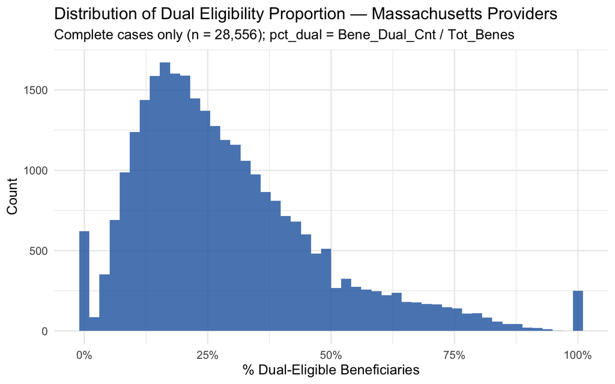

Distribution of dual eligibility proportion among providers with non-suppressed Bene_Dual_Cnt (n = 28,556). Right skew with a spike at 100% indicates most providers serve moderate proportions of dual-eligible patients, with a small subset serving exclusively dual-eligible panels.

```r
ggplot(ma_providers_rq3, aes(x = pct_dual)) +
  geom_histogram(bins = 50, fill = "#2166AC", alpha = 0.8) +
  scale_x_continuous(labels = scales::percent) +
  labs(
    title    = "Distribution of Dual Eligibility Proportion — Massachusetts Providers",
    subtitle = "Complete cases only (n = 28,556); pct_dual = Bene_Dual_Cnt / Tot_Benes",
    x        = "% Dual-Eligible Beneficiaries",
    y        = "Count"
  )
```

```r
cat("── pct_drug summary (after zero-imputation) ──\n")
```

```
## ── pct_drug summary (after zero-imputation) ──
```

```r
summary(ma_providers$pct_drug)
```

```
##    Min. 1st Qu.  Median    Mean 3rd Qu.    Max.
## 0.00000 0.00000 0.00000 0.02853 0.00000 0.99813
```

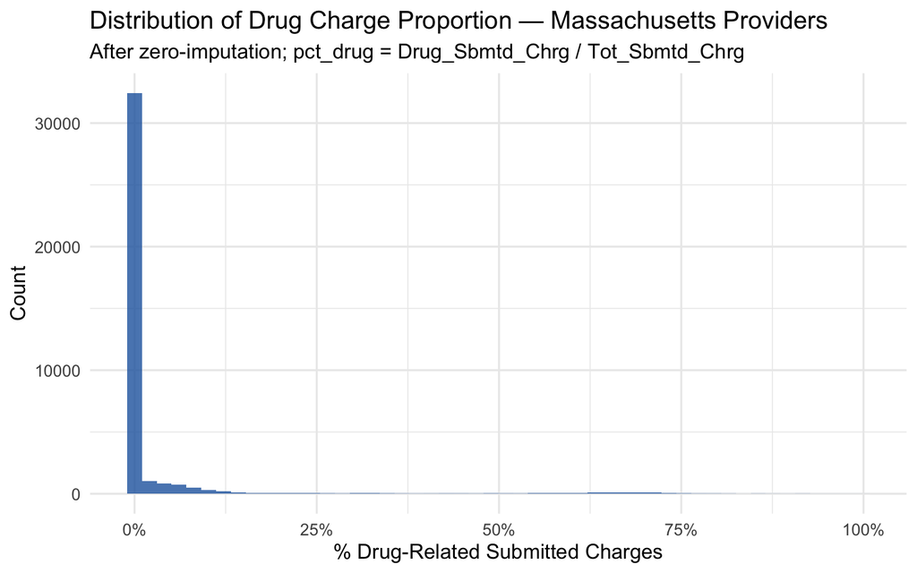

Distribution of drug charge proportion after zero-imputation (n = 37,708). The near-complete concentration at zero confirms the binary drug_provider encoding is the appropriate representation for this variable.

```r
ggplot(ma_providers, aes(x = pct_drug)) +
  geom_histogram(bins = 50, fill = "#2166AC", alpha = 0.8) +
  scale_x_continuous(labels = scales::percent) +
  labs(
    title    = "Distribution of Drug Charge Proportion — Massachusetts Providers",
    subtitle = "After zero-imputation; pct_drug = Drug_Sbmtd_Chrg / Tot_Sbmtd_Chrg",
    x        = "% Drug-Related Submitted Charges",
    y        = "Count"
  )
```

```r
# High gap rate by drug_provider
ma_providers_rq3 %>%
  group_by(drug_provider) %>%
  summarise(
    n            = n(),
    pct_high_gap = round(mean(high_gap) * 100, 1)
  )
```

| drug_provider | n | pct_high_gap |
| --- | --- | --- |
| 0 | 22730 | 59.6 |
| 1 | 5826 | 72.0 |

```r
# Numeric predictor summaries by high_gap
ma_providers_rq3 %>%
  group_by(high_gap) %>%
  summarise(
    median_benes     = median(Tot_Benes),
    median_srvcs     = round(median(srvcs_per_bene), 2),
    median_risk      = round(median(Bene_Avg_Risk_Scre), 3),
    median_dual      = round(median(pct_dual), 3),
    median_hcpcs     = median(Tot_HCPCS_Cds)
  )
```

| high_gap | median_benes | median_srvcs | median_risk | median_dual | median_hcpcs |
| --- | --- | --- | --- | --- | --- |
| 0 | 99 | 2.07 | 1.298 | 0.310 | 11 |
| 1 | 315 | 2.56 | 1.476 | 0.224 | 29 |

```r
cat("── Tot_HCPCS_Cds summary ──\n")
```

```
## ── Tot_HCPCS_Cds summary ──
```

```r
summary(ma_providers_rq3$Tot_HCPCS_Cds)
```

```
##    Min. 1st Qu.  Median    Mean 3rd Qu.    Max.
##    1.00   10.00   19.00   28.27   37.00  705.00
```

```r
cat("── Tot_Benes summary ──\n")
```

```
## ── Tot_Benes summary ──
```

```r
summary(ma_providers_rq3$Tot_Benes)
```

```
##     Min.  1st Qu.   Median     Mean  3rd Qu.     Max.
##     11.0    108.0    214.0    396.1    405.0 203417.0
```

```r
cat("── srvcs_per_bene summary ──\n")
```

```
## ── srvcs_per_bene summary ──
```

```r
summary(ma_providers_rq3$srvcs_per_bene)
```

```
##    Min. 1st Qu.  Median    Mean 3rd Qu.    Max.
##   1.000   1.560   2.350   4.977   4.103 695.636
```

```r
cat("\n── Tot_HCPCS_Cds distribution by high_gap ──\n")
```

```
##
## ── Tot_HCPCS_Cds distribution by high_gap ──
```

```r
ma_providers_rq3 %>%
  group_by(high_gap) %>%
  summarise(
    n       = n(),
    median  = median(Tot_HCPCS_Cds),
    mean    = round(mean(Tot_HCPCS_Cds), 1),
    p25     = quantile(Tot_HCPCS_Cds, 0.25),
    p75     = quantile(Tot_HCPCS_Cds, 0.75),
    .groups = "drop"
  ) %>%
  print()
```

```
## # A tibble: 2 × 6
##   high_gap     n median  mean   p25   p75
##      <dbl> <int>  <dbl> <dbl> <dbl> <dbl>
## 1        0 10819     11  14.8     7    18
## 2        1 17737     29  36.5    15    47
```

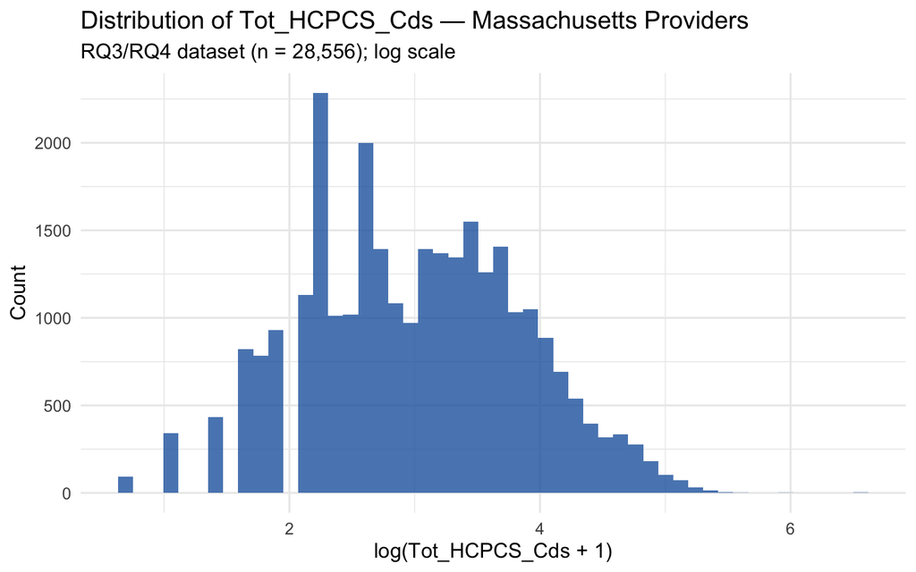

```r
ggplot(ma_providers_rq3, aes(x = log(Tot_HCPCS_Cds + 1))) +
  geom_histogram(bins = 50, fill = "#2166AC", alpha = 0.8) +
  labs(
    title    = "Distribution of Tot_HCPCS_Cds — Massachusetts Providers",
    subtitle = "RQ3/RQ4 dataset (n = 28,556); log scale",
    x        = "log(Tot_HCPCS_Cds + 1)",
    y        = "Count"
  )
```

```r
# Distribution of pct_dual by high_gap
ma_providers_rq3 %>%
  group_by(high_gap) %>%
  summarise(
    n       = n(),
    median  = round(median(pct_dual), 3),
    mean    = round(mean(pct_dual), 3),
    p25     = round(quantile(pct_dual, 0.25), 3),
    p75     = round(quantile(pct_dual, 0.75), 3)
  )
```

| high_gap | n | median | mean | p25 | p75 |
| --- | --- | --- | --- | --- | --- |
| 0 | 10819 | 0.310 | 0.350 | 0.181 | 0.485 |
| 1 | 17737 | 0.224 | 0.253 | 0.145 | 0.331 |

```r
# Split pct_dual at median and compare payment gap
ma_providers_rq3 %>%
  mutate(high_dual = ifelse(pct_dual > median(pct_dual),
                            "High dual", "Low dual")) %>%
  group_by(high_dual) %>%
  summarise(
    n          = n(),
    median_gap = round(median(payment_gap)),
    mean_gap   = round(mean(payment_gap)),
    p25_gap    = round(quantile(payment_gap, 0.25)),
    p75_gap    = round(quantile(payment_gap, 0.75))
  )
```

| high_dual | n | median_gap | mean_gap | p25_gap | p75_gap |
| --- | --- | --- | --- | --- | --- |
| High dual | 14278 | 99942 | 235487 | 43608 | 213918 |
| Low dual | 14278 | 176569 | 386708 | 72552 | 381801 |

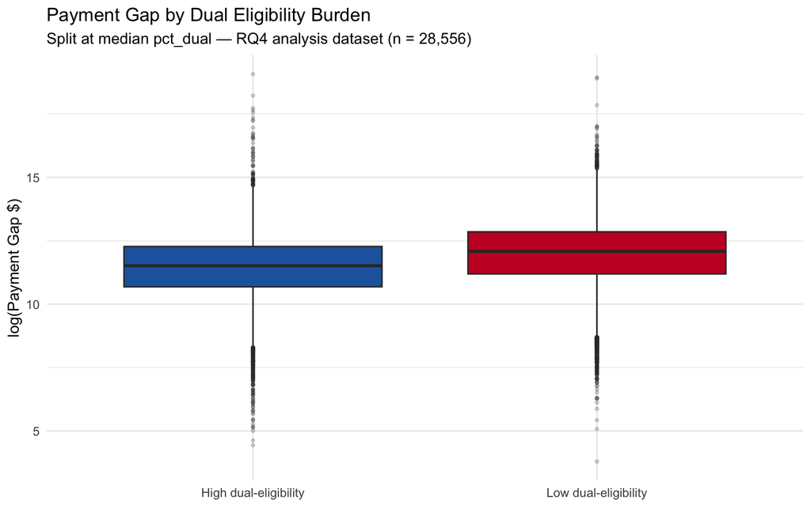

```r
ma_providers_rq3 %>%
  mutate(high_dual = ifelse(pct_dual > median(pct_dual),
                            "High dual-eligibility",
                            "Low dual-eligibility")) %>%
  ggplot(aes(x = high_dual, y = log(payment_gap), fill = high_dual)) +
  geom_boxplot(outlier.alpha = 0.2, outlier.size = 0.8) +
  scale_fill_manual(values = c("#2166AC", "#C8102E")) +
  labs(
    title    = "Payment Gap by Dual Eligibility Burden",
    subtitle = "Split at median pct_dual — RQ4 analysis dataset (n = 28,556)",
    x        = NULL,
    y        = "log(Payment Gap $)"
  ) +
  theme_minimal() +
  theme(legend.position = "none")
```

::: why-box **Why examine pct_dual as a continuous predictor?** RQ4 splits providers at the median into two equal groups and compares their median payment gaps. This binary split is analytically convenient but raises a question: does the median cutoff mask a more complex underlying relationship? If the association between dual-eligibility burden and the payment gap is non-linear — for example, if it accelerates above a certain threshold or is flat for most of the range and only kicks in at the extremes — the binary comparison would give a misleading picture of the true relationship.

**Reading the continuous pct_dual plot:** Each grey dot is one provider from a random sample of 5,000. The x-axis shows the proportion of dual-eligible beneficiaries in a provider’s patient panel, ranging from 0% (no dual-eligible patients) to 100% (all patients are dual-eligible). The y-axis shows the log payment gap.

**What to look for:** straight parallel lines indicate a linear, uniform relationship — the same slope at every quantile, meaning dual-eligibility burden shifts the gap distribution downward by the same amount regardless of where a provider sits in the distribution. Curved lines would indicate non-linearity. Diverging or converging lines would indicate that the effect differs between low-gap and high-gap providers.

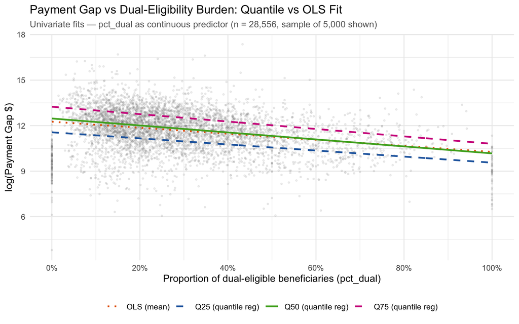

```r
library(quantreg)
library(ggrepel)

# Sample for plotting to avoid overplotting
set.seed(6105)
plot_sample <- ma_providers_rq3 %>% sample_n(5000)

# Fit univariate quantile regression lines for motivation
qr_25_d <- rq(log(payment_gap) ~ pct_dual, tau = 0.25, data = ma_providers_rq3)
qr_50_d <- rq(log(payment_gap) ~ pct_dual, tau = 0.50, data = ma_providers_rq3)
qr_75_d <- rq(log(payment_gap) ~ pct_dual, tau = 0.75, data = ma_providers_rq3)
ols_d   <- lm(log(payment_gap) ~ pct_dual, data = ma_providers_rq3)

# Prediction grid across full range of pct_dual
dual_grid <- data.frame(pct_dual = seq(0, 1, length.out = 300))

pred_df_d <- dual_grid %>%
  mutate(
    q25 = predict(qr_25_d, newdata = dual_grid),
    q50 = predict(qr_50_d, newdata = dual_grid),
    q75 = predict(qr_75_d, newdata = dual_grid),
    ols = predict(ols_d,   newdata = dual_grid)
  ) %>%
  pivot_longer(
    cols      = c(q25, q50, q75, ols),
    names_to  = "model",
    values_to = "fitted_log_gap"
  )

ggplot() +
  geom_point(
    data  = plot_sample,
    aes(x = pct_dual, y = log(payment_gap)),
    alpha = 0.12, size = 0.6, colour = "grey50"
  ) +
  geom_line(
    data = pred_df_d,
    aes(x = pct_dual, y = fitted_log_gap,
        colour = model, linetype = model),
    linewidth = 0.9
  ) +
  scale_colour_manual(
    values = c(
      q25 = "#2166AC",
      q50 = "#4DAC26",
      q75 = "#D01C8B",
      ols = "#E66101"
    ),
    labels = c(
      q25 = "Q25 (quantile reg)",
      q50 = "Q50 (quantile reg)",
      q75 = "Q75 (quantile reg)",
      ols = "OLS (mean)"
    )
  ) +
  scale_linetype_manual(
    values = c(
      q25 = "dashed",
      q50 = "solid",
      q75 = "dashed",
      ols = "dotted"
    ),
    labels = c(
      q25 = "Q25 (quantile reg)",
      q50 = "Q50 (quantile reg)",
      q75 = "Q75 (quantile reg)",
      ols = "OLS (mean)"
    )
  ) +
  scale_x_continuous(
    labels = scales::percent,
    breaks = seq(0, 1, by = 0.2)
  ) +
  labs(
    title    = "Payment Gap vs Dual-Eligibility Burden: Quantile vs OLS Fit",
    subtitle = "Univariate fits — pct_dual as continuous predictor (n = 28,556, sample of 5,000 shown)",
    x        = "Proportion of dual-eligible beneficiaries (pct_dual)",
    y        = "log(Payment Gap $)",
    colour   = NULL,
    linetype = NULL
  ) +
  theme_minimal() +
  theme(
    plot.title      = element_text(size = 13),
    plot.subtitle   = element_text(size = 10, colour = "grey40"),
    legend.position = "bottom"
  )
```

```r
ggsave(
  here::here("docs", "figures", "pct_dual_continuous_motivation.png"),
  width = 8, height = 5, dpi = 300
)
```

These results justify the binary split used in RQ4. The median cutoff was not masking a threshold effect or non-linearity — it was summarising a smooth, linear, and uniform continuous relationship. The $76{,}628 difference in median gaps between low and high dual-eligibility providers reflects a consistent gradient that runs across the full spectrum of dual-eligibility burden rather than a step change at the median.

# Part 10: chronic condition variable selection

**Two regression analyses for RQ1:**

Before running LASSO, the complete-CC subset is profiled against the full dataset to establish whether it represents a genuinely distinct analytical population or simply replicates the high-volume vs low-volume split identified in Part 3. If the two groups differ only in provider volume, the complete-CC model should be interpreted as a high-volume provider analysis rather than a true sensitivity check.

## Step 1: profiling the complete-CC subset

```r
# Create complete-CC subset
ma_providers_cc <- ma_providers %>%
  filter(!any_cc_missing)

cat("── Full dataset vs complete-CC subset ──\n")
```

```
## ── Full dataset vs complete-CC subset ──
```

```r
bind_rows(
  ma_providers %>%
    summarise(
      dataset       = "Full",
      n             = n(),
      median_benes  = median(Tot_Benes),
      mean_benes    = round(mean(Tot_Benes), 1),
      median_gap    = round(median(payment_gap)),
      mean_gap      = round(mean(payment_gap)),
      median_risk   = round(median(Bene_Avg_Risk_Scre), 3),
      median_srvcs  = round(median(srvcs_per_bene), 2)
    ),
  ma_providers_cc %>%
    summarise(
      dataset       = "Complete CC",
      n             = n(),
      median_benes  = median(Tot_Benes),
      mean_benes    = round(mean(Tot_Benes), 1),
      median_gap    = round(median(payment_gap)),
      mean_gap      = round(mean(payment_gap)),
      median_risk   = round(median(Bene_Avg_Risk_Scre), 3),
      median_srvcs  = round(median(srvcs_per_bene), 2)
    )
) %>%
  print()
```

```
## # A tibble: 2 × 8
##   dataset         n median_benes mean_benes median_gap mean_gap median_risk
##   <chr>       <int>        <dbl>      <dbl>      <dbl>    <dbl>       <dbl>
## 1 Full        37708         149        312.      89292   247753        1.33
## 2 Complete CC  3752         928.      1424.     404539   979287        1.73
## # ℹ 1 more variable: median_srvcs <dbl>
```

```r
cat("\n── Top 10 specialties: full dataset ──\n")
```

```
##
## ── Top 10 specialties: full dataset ──
```

```r
ma_providers %>%
  count(Rndrng_Prvdr_Type, sort = TRUE) %>%
  mutate(pct = round(n / sum(n) * 100, 1)) %>%
  head(10) %>%
  print()
```

```
## # A tibble: 10 × 3
##    Rndrng_Prvdr_Type                          n   pct
##    <chr>                                  <int> <dbl>
##  1 Nurse Practitioner                      5496  14.6
##  2 Internal Medicine                       3978  10.5
##  3 Physician Assistant                     3070   8.1
##  4 Physical Therapist in Private Practice  2005   5.3
##  5 Anesthesiology                          1375   3.6
##  6 Family Practice                         1335   3.5
##  7 Emergency Medicine                      1299   3.4
##  8 Diagnostic Radiology                    1118   3
##  9 Licensed Clinical Social Worker         1044   2.8
## 10 Psychiatry                              1033   2.7
```

```r
cat("\n── Top 10 specialties: complete-CC subset ──\n")
```

```
##
## ── Top 10 specialties: complete-CC subset ──
```

```r
ma_providers_cc %>%
  count(Rndrng_Prvdr_Type, sort = TRUE) %>%
  mutate(pct = round(n / sum(n) * 100, 1)) %>%
  head(10) %>%
  print()
```

```
## # A tibble: 10 × 3
##    Rndrng_Prvdr_Type              n   pct
##    <chr>                      <int> <dbl>
##  1 Diagnostic Radiology         789  21
##  2 Emergency Medicine           539  14.4
##  3 Cardiology                   376  10
##  4 Internal Medicine            282   7.5
##  5 Nurse Practitioner           148   3.9
##  6 Ophthalmology                133   3.5
##  7 Pathology                    124   3.3
##  8 Neurology                    117   3.1
##  9 Ambulance Service Provider   110   2.9
## 10 Hospitalist                  108   2.9
```

**Interpretation guidance:**

If the complete-CC subset shows a substantially higher median `Tot_Benes` than the full dataset, it confirms that the `Bene_CC_*` completeness split is driven by provider volume rather than any independent characteristic. In that case the LASSO model should be clearly labelled as a high-volume provider analysis in the write-up, and its coefficients should not be generalised to the full Massachusetts provider population. If the specialty distributions also diverge, that adds further evidence that the two models answer subtly different questions about different provider subpopulations.

## Step 2: LASSO variable selection

**Why LASSO rather than PCA?**

Both LASSO and PCA address the multicollinearity among `Bene_CC_*` variables, but they do so differently. PCA combines all variables into uncorrelated linear components, which eliminates multicollinearity but destroys interpretability — the components cannot be mapped back to specific chronic conditions. LASSO applies an L1 penalty that shrinks some coefficients exactly to zero, retaining a sparse set of original variables. Because RQ1 explicitly asks which factors have the strongest independent effect, LASSO is the appropriate tool: it preserves the ability to attribute effects to specific chronic conditions while controlling for multicollinearity through variable elimination.

```r
cc_cols <- ma_providers_cc %>%
  dplyr::select(starts_with("Bene_CC_")) %>%
  names()

lasso_vars <- c(cc_cols, "Bene_Avg_Risk_Scre", "Bene_Avg_Age", "srvcs_per_bene")

lasso_data <- ma_providers_cc %>%
  dplyr::select(all_of(lasso_vars), payment_gap) %>%
  drop_na()

X <- lasso_data %>%
  dplyr::select(all_of(lasso_vars)) %>%
  as.matrix()

y <- log(lasso_data$payment_gap)

set.seed(6105)
cv_lasso <- cv.glmnet(X, y, alpha = 1)

cat("── Optimal lambda (1se rule) ──\n")
```

```
## ── Optimal lambda (1se rule) ──
```

```r
cat(cv_lasso$lambda.1se, "\n")
```

```
## 0.05363878
```

```r
# ── Build coefficient data frame ──────────────────────────────────────────────
lasso_coefs <- coef(cv_lasso, s = "lambda.1se") %>%
  as.matrix() %>%
  as.data.frame() %>%
  tibble::rownames_to_column("variable") %>%
  dplyr::rename(coefficient = 2) %>%
  dplyr::filter(variable != "(Intercept)", coefficient != 0) %>%
  dplyr::arrange(desc(abs(coefficient))) %>%
  dplyr::mutate(
    direction = ifelse(coefficient > 0, "Positive", "Negative"),
    # Clean up variable names for the axis label
    label = variable %>%
      stringr::str_remove("^Bene_CC_") %>%
      stringr::str_replace_all("_", " ") %>%
      stringr::str_to_title() %>%
      dplyr::recode(
        "Bene Avg Risk Scre" = "Avg Risk Score",
        "Bene Avg Age"       = "Avg Age",
        "Srvcs Per Bene"     = "Services per Beneficiary"
      )
  )

cat("\n── Non-zero LASSO coefficients (lambda.1se) ──\n")
```

```
##
## ── Non-zero LASSO coefficients (lambda.1se) ──
```

```r
print(dplyr::select(lasso_coefs, variable, coefficient))
```

```
##                            variable  coefficient
## 1                Bene_Avg_Risk_Scre -0.102451145
## 2  Bene_CC_PH_Hyperlipidemia_V2_Pct  0.036230361
## 3    Bene_CC_PH_Hypertension_V2_Pct  0.026970148
## 4              Bene_CC_BH_PD_V1_Pct -0.021488322
## 5                    srvcs_per_bene  0.014399719
## 6                      Bene_Avg_Age  0.011619364
## 7          Bene_CC_PH_Asthma_V2_Pct -0.010698954
## 8            Bene_CC_BH_Mood_V2_Pct -0.007617768
## 9       Bene_CC_PH_Arthritis_V2_Pct  0.004464563
## 10  Bene_CC_BH_Alz_NonAlzdem_V2_Pct -0.004357801
## 11   Bene_CC_BH_Alcohol_Drug_V1_Pct -0.002820694
## 12      Bene_CC_PH_HF_NonIHD_V2_Pct -0.002733028
```

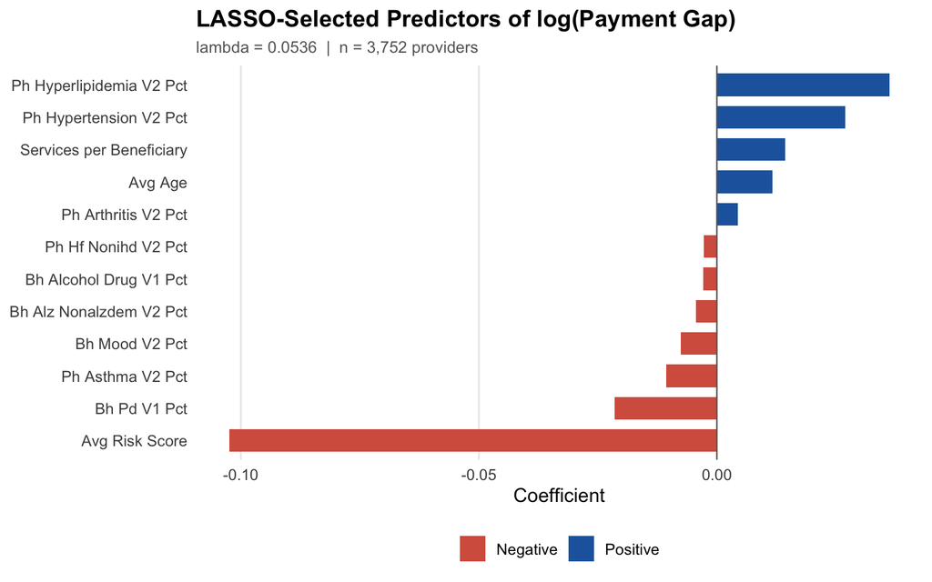

Non-zero LASSO coefficients at lambda.1se predicting log(payment_gap) among Massachusetts providers with complete chronic condition data (2023).

```r
# ── Plot ──────────────────────────────────────────────────────────────────────
p_lasso <- ggplot(
  lasso_coefs,
  aes(
    x    = reorder(label, coefficient),
    y    = coefficient,
    fill = direction
  )
) +
  geom_col(width = 0.7) +
  geom_hline(yintercept = 0, linewidth = 0.4, colour = "grey40") +
  coord_flip() +
  scale_fill_manual(
    values = c("Positive" = "#2166AC", "Negative" = "#D6604D"),
    name   = NULL
  ) +
  labs(
    title    = "LASSO-Selected Predictors of log(Payment Gap)",
    subtitle = paste0(
      "lambda = ", round(cv_lasso$lambda.1se, 4),
      "  |  n = ", scales::comma(nrow(lasso_data)), " providers"
    ),
    x = NULL,
    y = "Coefficient"
  ) +
  theme_minimal(base_size = 12) +
  theme(
    legend.position  = "bottom",
    panel.grid.major.y = element_blank(),
    panel.grid.minor   = element_blank(),
    plot.title    = element_text(face = "bold"),
    plot.subtitle = element_text(colour = "grey40", size = 10)
  )

print(p_lasso)
```

```r
# ── Export ────────────────────────────────────────────────────────────────────
ggsave(
  here::here("docs", "figures", "lasso_coefficients.png"),
  plot   = p_lasso,
  width  = 7,
  height = max(4, nrow(lasso_coefs) * 0.45),   # scales height with # of bars
  dpi    = 300
)
```

## Step 3: correlation matrix of retained variables

**Why inspect correlations after LASSO?**

LASSO selects variables independently of their pairwise correlations — it can retain two highly correlated variables if both carry independent signal. The correlation matrix below checks whether any retained `Bene_CC_*` variables remain strongly correlated with each other (|r| > 0.7), which would indicate residual multicollinearity worth addressing through further pruning before the regression. Correlations with log payment gap also give a first indication of the direction and strength of each variable’s relationship with the outcome.

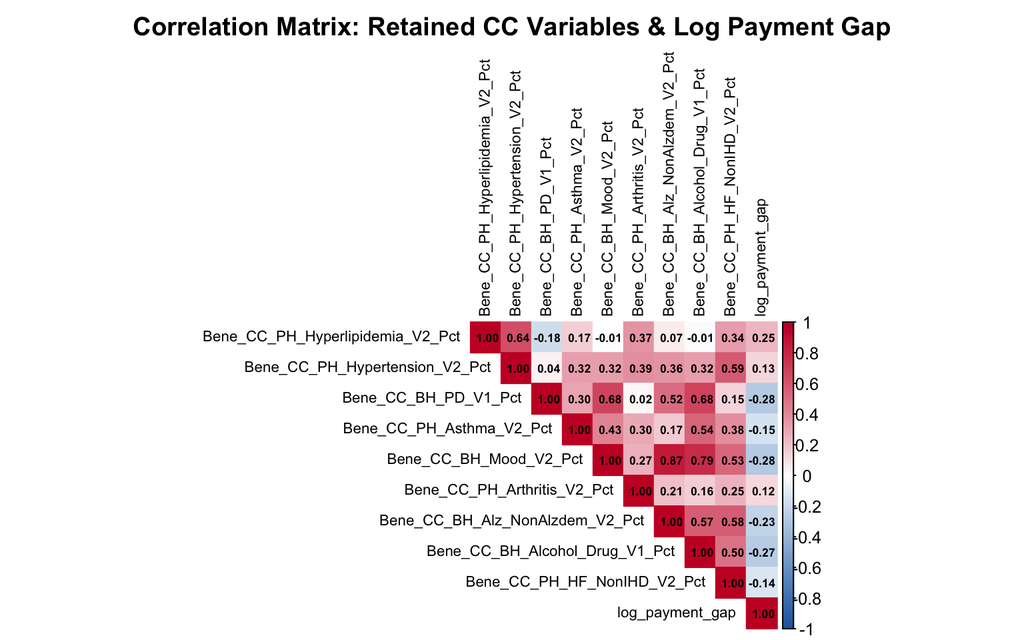

Pearson correlation matrix of LASSO-retained chronic condition variables and log payment gap. Values above |0.7| between predictors indicate residual multicollinearity.

```r
retained_cc <- lasso_coefs %>%
  filter(str_detect(variable, "Bene_CC_")) %>%
  pull(variable)

cor_data <- ma_providers_cc %>%
  dplyr::select(all_of(retained_cc), payment_gap) %>%
  drop_na() %>%
  mutate(log_payment_gap = log(payment_gap)) %>%
  dplyr::select(-payment_gap)

cor_matrix <- cor(cor_data, use = "complete.obs")

corrplot(
  cor_matrix,
  method      = "color",
  type        = "upper",
  tl.cex      = 0.7,
  tl.col      = "black",
  addCoef.col = "black",
  number.cex  = 0.55,
  col         = colorRampPalette(c("#2166AC", "white", "#C8102E"))(200),
  title       = "Correlation Matrix: Retained CC Variables & Log Payment Gap",
  mar         = c(0, 0, 2, 0)
)
```

```r
print(round(cor_matrix, 2))
```

```
##                                  Bene_CC_PH_Hyperlipidemia_V2_Pct
## Bene_CC_PH_Hyperlipidemia_V2_Pct                             1.00
## Bene_CC_PH_Hypertension_V2_Pct                               0.64
## Bene_CC_BH_PD_V1_Pct                                        -0.18
## Bene_CC_PH_Asthma_V2_Pct                                     0.17
## Bene_CC_BH_Mood_V2_Pct                                      -0.01
## Bene_CC_PH_Arthritis_V2_Pct                                  0.37
## Bene_CC_BH_Alz_NonAlzdem_V2_Pct                              0.07
## Bene_CC_BH_Alcohol_Drug_V1_Pct                              -0.01
## Bene_CC_PH_HF_NonIHD_V2_Pct                                  0.34
## log_payment_gap                                              0.25
##                                  Bene_CC_PH_Hypertension_V2_Pct
## Bene_CC_PH_Hyperlipidemia_V2_Pct                           0.64
## Bene_CC_PH_Hypertension_V2_Pct                             1.00
## Bene_CC_BH_PD_V1_Pct                                       0.04
## Bene_CC_PH_Asthma_V2_Pct                                   0.32
## Bene_CC_BH_Mood_V2_Pct                                     0.32
## Bene_CC_PH_Arthritis_V2_Pct                                0.39
## Bene_CC_BH_Alz_NonAlzdem_V2_Pct                            0.36
## Bene_CC_BH_Alcohol_Drug_V1_Pct                             0.32
## Bene_CC_PH_HF_NonIHD_V2_Pct                                0.59
## log_payment_gap                                            0.13
##                                  Bene_CC_BH_PD_V1_Pct Bene_CC_PH_Asthma_V2_Pct
## Bene_CC_PH_Hyperlipidemia_V2_Pct                -0.18                     0.17
## Bene_CC_PH_Hypertension_V2_Pct                   0.04                     0.32
## Bene_CC_BH_PD_V1_Pct                             1.00                     0.30
## Bene_CC_PH_Asthma_V2_Pct                         0.30                     1.00
## Bene_CC_BH_Mood_V2_Pct                           0.68                     0.43
## Bene_CC_PH_Arthritis_V2_Pct                      0.02                     0.30
## Bene_CC_BH_Alz_NonAlzdem_V2_Pct                  0.52                     0.17
## Bene_CC_BH_Alcohol_Drug_V1_Pct                   0.68                     0.54
## Bene_CC_PH_HF_NonIHD_V2_Pct                      0.15                     0.38
## log_payment_gap                                 -0.28                    -0.15
##                                  Bene_CC_BH_Mood_V2_Pct
## Bene_CC_PH_Hyperlipidemia_V2_Pct                  -0.01
## Bene_CC_PH_Hypertension_V2_Pct                     0.32
## Bene_CC_BH_PD_V1_Pct                               0.68
## Bene_CC_PH_Asthma_V2_Pct                           0.43
## Bene_CC_BH_Mood_V2_Pct                             1.00
## Bene_CC_PH_Arthritis_V2_Pct                        0.27
```

[output cut: 33 more lines]

```
## Bene_CC_BH_Alz_NonAlzdem_V2_Pct                            0.57
## Bene_CC_BH_Alcohol_Drug_V1_Pct                             1.00
## Bene_CC_PH_HF_NonIHD_V2_Pct                                0.50
## log_payment_gap                                           -0.27
##                                  Bene_CC_PH_HF_NonIHD_V2_Pct log_payment_gap
## Bene_CC_PH_Hyperlipidemia_V2_Pct                        0.34            0.25
## Bene_CC_PH_Hypertension_V2_Pct                          0.59            0.13
## Bene_CC_BH_PD_V1_Pct                                    0.15           -0.28
## Bene_CC_PH_Asthma_V2_Pct                                0.38           -0.15
## Bene_CC_BH_Mood_V2_Pct                                  0.53           -0.28
## Bene_CC_PH_Arthritis_V2_Pct                             0.25            0.12
## Bene_CC_BH_Alz_NonAlzdem_V2_Pct                         0.58           -0.23
## Bene_CC_BH_Alcohol_Drug_V1_Pct                          0.50           -0.27
## Bene_CC_PH_HF_NonIHD_V2_Pct                             1.00           -0.14
## log_payment_gap                                        -0.14            1.00
```

# Part 11: save preprocessed dataset

```r
# Save provider-level preprocessed dataset for downstream analyses
saveRDS(ma_providers, "../data/processed/ma_providers_preprocessed.rds")
cat("Saved: ma_providers_preprocessed.rds\n")
```

```
## Saved: ma_providers_preprocessed.rds
```

```r
cat("Rows:", nrow(ma_providers), "\n")
```

```
## Rows: 37708
```

```r
cat("Columns:", ncol(ma_providers), "\n")
```

```
## Columns: 88
```

```r
saveRDS(ma_providers_rq3, "../data/processed/ma_providers_rq3.rds")
cat("Saved: ma_providers_rq3.rds\n")
```

```
## Saved: ma_providers_rq3.rds
```

```r
cat("Rows:", nrow(ma_providers_rq3), "\n")
```

```
## Rows: 28556
```

```r
cat("Columns:", ncol(ma_providers_rq3), "\n")
```

```
## Columns: 88
```